# kamisdata: Sheila Gank

IFN

9/17/2019

```r
library(tidyverse)
library(corrplot)
```

```r
plot_theme <- theme(legend.position = 'top',
                    panel.background = element_rect(fill = 'white'),
                    panel.grid.major = element_line(colour = 'grey'),
                    panel.grid.minor = element_line(colour = 'grey',
                                                    linetype = 3),
                    panel.border = element_rect(colour = 'black',
                                                fill = NA),
                    plot.title = element_text(hjust = 0.5))
```

## Top Streamed Local Artist 2018

Load data dari folder `data`.

```r
load("../data/top_streamed_indonesia.rda")
head(top_streamed_indonesia)
```

| playcount | disc | number | uri | id | danceability | energy | key | loudness | mode | speechiness | acousticness | instrumentalness | liveness | valence | tempo | duration_ms | time_signature | album | name.y | artist |
| --- | --- | --- | --- | --- | --- | --- | --- | --- | --- | --- | --- | --- | --- | --- | --- | --- | --- | --- | --- | --- |
| 1037951 | 1 | 1 | spotify:track:3AmI1juQjQRHHNyymm5vFH | 3AmI1juQjQRHHNyymm5vFH | 0.598 | 0.876 | 7 | -4.726 | 1 | 0.0430 | 0.0202 | 2.38e-06 | 0.170 | 0.855 | 74.986 | 227987 | 4 | Musim Yang Baik | Selamat Datang | Sheila On 7 |
| 1037951 | 1 | 1 | spotify:track:3AmI1juQjQRHHNyymm5vFH | 3AmI1juQjQRHHNyymm5vFH | 0.598 | 0.876 | 7 | -4.726 | 1 | 0.0430 | 0.0202 | 2.38e-06 | 0.170 | 0.855 | 74.986 | 227987 | 4 | Musim Yang Baik | Selamat Datang | Sheila On 7 |
| 756242 | 1 | 2 | spotify:track:6BPQJZdiKJxY0jEirC5Xbo | 6BPQJZdiKJxY0jEirC5Xbo | 0.720 | 0.882 | 9 | -5.501 | 1 | 0.0393 | 0.0298 | 1.31e-04 | 0.223 | 0.960 | 129.990 | 198950 | 4 | Musim Yang Baik | Satu Langkah | Sheila On 7 |
| 756242 | 1 | 2 | spotify:track:6BPQJZdiKJxY0jEirC5Xbo | 6BPQJZdiKJxY0jEirC5Xbo | 0.720 | 0.882 | 9 | -5.501 | 1 | 0.0393 | 0.0298 | 1.31e-04 | 0.223 | 0.960 | 129.990 | 198950 | 4 | Musim Yang Baik | Satu Langkah | Sheila On 7 |
| 620768 | 1 | 3 | spotify:track:0vRSrbdyrHPDhCX1MwJuh3 | 0vRSrbdyrHPDhCX1MwJuh3 | 0.734 | 0.708 | 4 | -5.717 | 0 | 0.0571 | 0.2610 | 2.96e-05 | 0.116 | 0.866 | 104.957 | 253122 | 4 | Musim Yang Baik | Buka Mata Buka Telinga | Sheila On 7 |
| 620768 | 1 | 3 | spotify:track:0vRSrbdyrHPDhCX1MwJuh3 | 0vRSrbdyrHPDhCX1MwJuh3 | 0.734 | 0.708 | 4 | -5.717 | 0 | 0.0571 | 0.2610 | 2.96e-05 | 0.116 | 0.866 | 104.957 | 253122 | 4 | Musim Yang Baik | Buka Mata Buka Telinga | Sheila On 7 |

```r
names(top_streamed_indonesia)
```

```
##  [1] "playcount"        "disc"             "number"
##  [4] "uri"              "id"               "danceability"
##  [7] "energy"           "key"              "loudness"
## [10] "mode"             "speechiness"      "acousticness"
## [13] "instrumentalness" "liveness"         "valence"
## [16] "tempo"            "duration_ms"      "time_signature"
## [19] "album"            "name.y"           "artist"
```

```r
top_streamed_indonesia <- top_streamed_indonesia %>%
  distinct()
dim(top_streamed_indonesia)
```

```
## [1] 223  21
```

```r
top_streamed_indonesia$playcount <- as.numeric(top_streamed_indonesia$playcount)
```

```r
sheila <- top_streamed_indonesia %>%
  filter(artist == "Sheila On 7") %>%
  select(-c("disc", "uri", "id")) # drop variable yang tidak diperlukan
head(sheila)
```

| playcount | number | danceability | energy | key | loudness | mode | speechiness | acousticness | instrumentalness | liveness | valence | tempo | duration_ms | time_signature | album | name.y | artist |
| --- | --- | --- | --- | --- | --- | --- | --- | --- | --- | --- | --- | --- | --- | --- | --- | --- | --- |
| 1037951 | 1 | 0.598 | 0.876 | 7 | -4.726 | 1 | 0.0430 | 0.0202 | 2.38e-06 | 0.170 | 0.855 | 74.986 | 227987 | 4 | Musim Yang Baik | Selamat Datang | Sheila On 7 |
| 756242 | 2 | 0.720 | 0.882 | 9 | -5.501 | 1 | 0.0393 | 0.0298 | 1.31e-04 | 0.223 | 0.960 | 129.990 | 198950 | 4 | Musim Yang Baik | Satu Langkah | Sheila On 7 |
| 620768 | 3 | 0.734 | 0.708 | 4 | -5.717 | 0 | 0.0571 | 0.2610 | 2.96e-05 | 0.116 | 0.866 | 104.957 | 253122 | 4 | Musim Yang Baik | Buka Mata Buka Telinga | Sheila On 7 |
| 793351 | 4 | 0.603 | 0.760 | 0 | -5.181 | 1 | 0.0542 | 0.3470 | 0.00e+00 | 0.211 | 0.681 | 148.008 | 220127 | 4 | Musim Yang Baik | Canggung | Sheila On 7 |
| 543033 | 5 | 0.582 | 0.718 | 9 | -4.627 | 1 | 0.0273 | 0.1680 | 0.00e+00 | 0.075 | 0.452 | 82.005 | 226930 | 4 | Musim Yang Baik | My Lovely | Sheila On 7 |
| 571854 | 6 | 0.584 | 0.808 | 2 | -4.942 | 1 | 0.0317 | 0.2930 | 2.92e-06 | 0.123 | 0.597 | 160.046 | 256478 | 4 | Musim Yang Baik | Beruntungnya Aku | Sheila On 7 |

## Sheila On 7

### Analisis Playcount

Sheila On 7 merupakan band lokal yang paling banyak di stream pada tahun 2018 menurut Spotify. Lagu apa yang sering di stream? Ternyata lagu yang paling banyak di stream adalah lagu **Dan…**. Ternyata masih banyak pengguna spotify yang menyukai lagu lagu lawas. Selain Sheila On 7, Payung Teduh menjadi artist yang paling banyak di stream dengan lagunya yang dimainkan di setiap resepsi pernikahan.

```r
top_streamed_indonesia %>%
  select(artist, name.y, playcount) %>%
  rename(Artist = artist, "Judul Lagu" = name.y, Playcount = playcount) %>%
  arrange(-Playcount) %>%
  top_n(10)
```

| Artist | Judul Lagu | Playcount |
| --- | --- | --- |
| Sheila On 7 | Dan... | 33715948 |
| Payung Teduh | Untuk Perempuan Yang Sedang Di Pelukan | 32209467 |
| Payung Teduh | Akad | 30076189 |
| Sheila On 7 | Seberapa Pantas | 18763248 |
| Sheila On 7 | Kita - Acoustic | 13685066 |
| Sheila On 7 | Hari Bersamanya - Accoustic Version | 13624840 |
| Sheila On 7 | Anugerah Terindah Yang Pernah Kumiliki | 12036065 |
| Payung Teduh | Di Atas Meja | 10515756 |
| Sheila On 7 | Melompat Lebih Tinggi | 10097345 |
| Payung Teduh | Resah | 9397698 |

Dari lagu-lagu Sheila On 7, apa lagu 10 besar yang paling banyak di stream? Tentu saja **Dan…** nomor satu. Lebih jauh lagi, lagu dari album mana saja yang di stream?

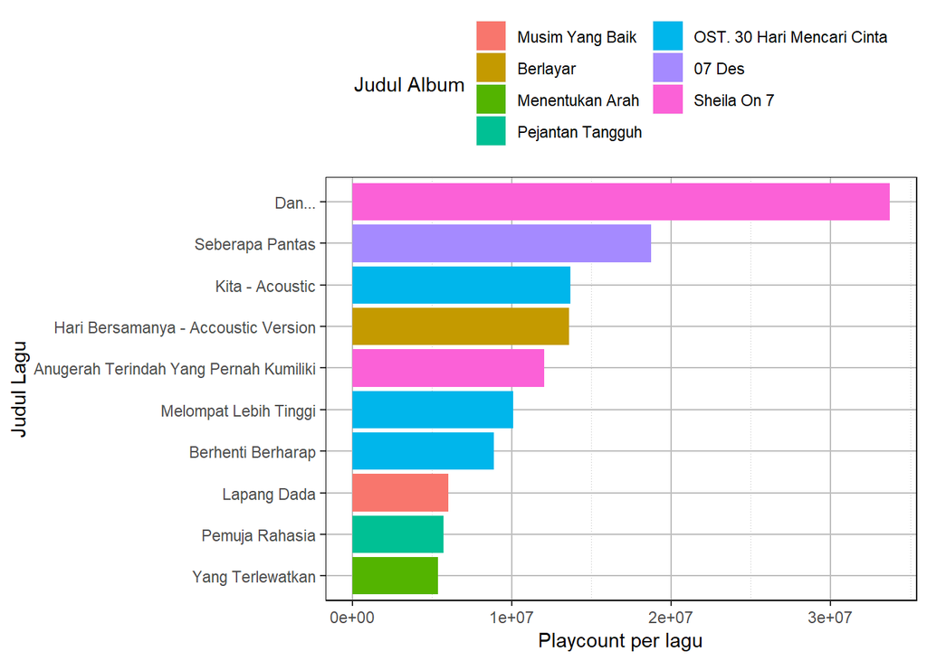

```r
sheila %>%
  top_n(10, playcount) %>%
  ggplot(aes(x = reorder(name.y, playcount), y = playcount,
             fill = album)) +
  geom_col() +
  coord_flip() +
  plot_theme +
  scale_fill_discrete(name = "Judul Album",
                      guide = guide_legend(nrow = 4)) + # membuat legend row menjadi 4
  labs(x = "Judul Lagu",
       y = "Playcount per lagu")
```

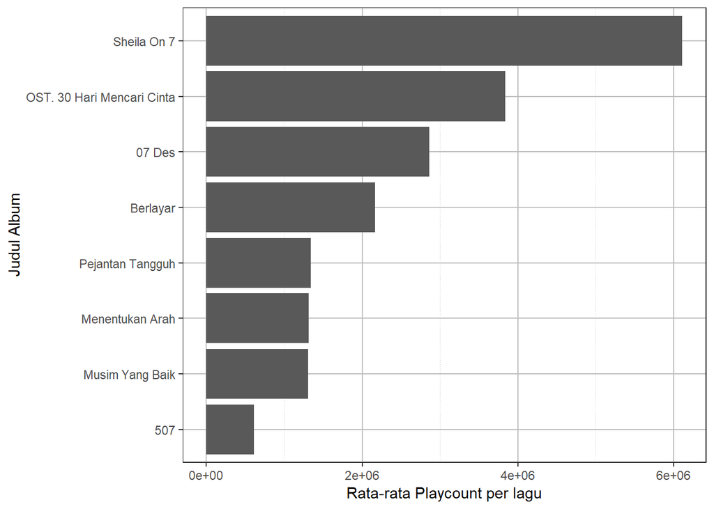

```r
sheila %>%
  group_by(album) %>%
  summarise(avg_play = mean(playcount, na.rm = TRUE)) %>%
  ggplot(aes(x = reorder(album, avg_play), y = avg_play)) +
  geom_col() +
  coord_flip() +
  plot_theme +
  labs(x = "Judul Album",
       y = "Rata-rata Playcount per lagu")
```

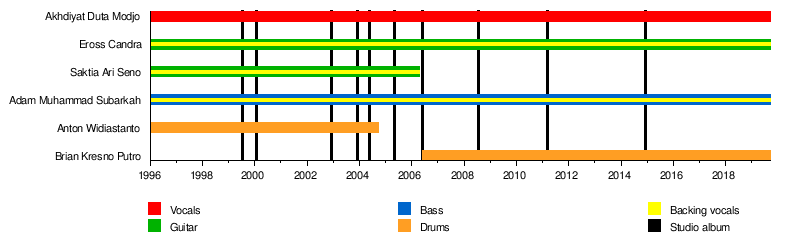

```r
knitr::include_graphics("./pictures/sheila_formasi.png")
```

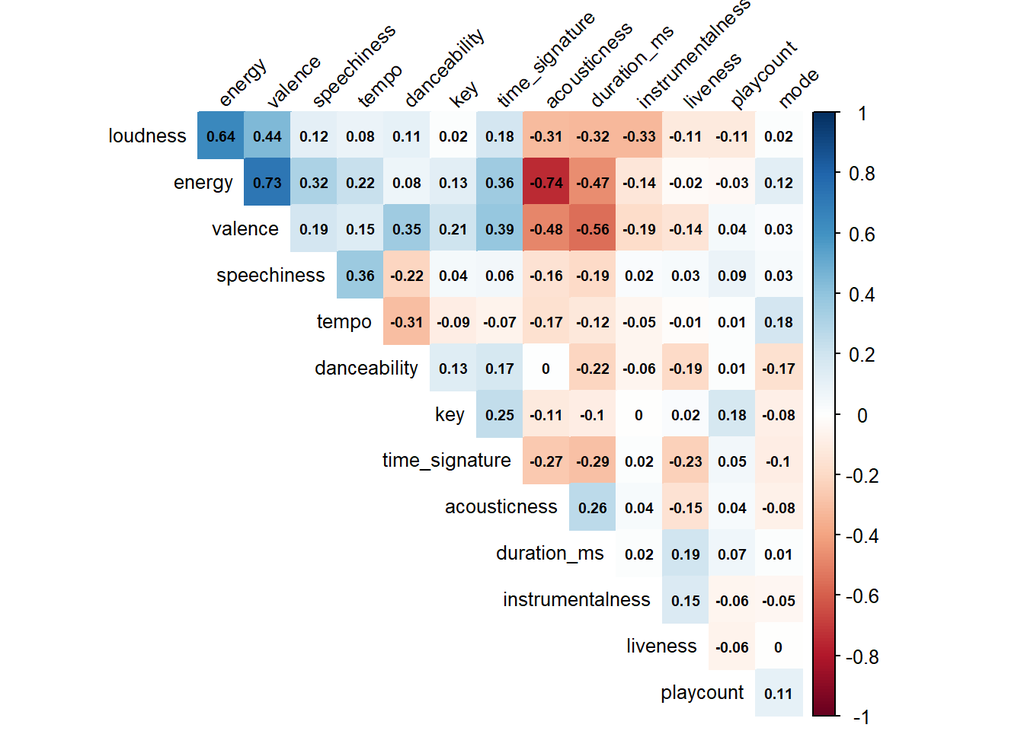

```r
top_streamed_indonesia %>%
  select_if(is.numeric) %>%
  filter(is.na(playcount) != TRUE) %>%
  cor() %>%
  corrplot(method = "color", order = "hclust", type = "upper",
           addCoef.col = "black", tl.col = "black",
           tl.srt = 45, diag = FALSE, tl.cex = 0.8, number.cex = 0.6)
```